# LSAdata OneWay ANOVA

```r
# loading libraries
library(tidyverse)
```

# One-way ANOVA data preparation (Wrangling)

## LDS Daniel chap 8 LSA_DATA

One-way ANOVA exercises with large data sets.  
Refer to the serum lipid-bound sialic acid data on 1400 subjects (LSADATA). We wish to conduct a study to determine if the measurement of serum lipid-bound sialic acid (LSA) might be of use in the detection of breast cancer. The LSA measurements (mg/dl) are for four populations of subjects: normal controls, A; patients with benign breast disease, B; patients with primary breast cancer, C; and patients with recurrent metastatic breast cancer, D. Select a simple random sample of size 10 from each population and perform an appropriate analysis to determine if we may conclude that the four population means are different.Let $\alpha = .05$ and determine the p value.

## Data import and tibble format

First we read the large data set (LDS) for the serum lipid-bound sialic acid data on 1400 subjects (LSADATA).

```r
# Reading from the stat class directory

LSAdata <- read_csv("~/Dropbox/GitHub/ProbEstad/DataSets/ch08_all/LDS_C08_LSADATA.csv")
LSAdata
```

```
# A tibble: 350 × 5
    Col1  Col2  Col3  Col4  Col5
   <dbl> <dbl> <dbl> <dbl> <dbl>
 1     1  18.8  24.3  19    22.3
 2     2  17.3  22.2  12.5  17.3
 3     3  16.4  19    21    20.8
 4     4  18.9  21.5  21.5  26.1
 5     5  14.7  24.6  18.5  25.1
 6     6  13.3  21.2  22.1  24.8
 7     7  16.9  18.8  26.2  23
 8     8  17.9  21.2  19.1  23.8
 9     9  18    20.3  22.2  25.1
10    10  20.9  22.6  18.8  25.3
# … with 340 more rows
```

From the raw data file the format is a tibble with variables for column and data point by rows, nevertheless to execute a one-way ANOVA we need to [wrangle](https://en.wikipedia.org/wiki/Data_wrangling) the data. Start by changing the column names according to the LDS problem description: Subject_number:Col1, Controls:Col2 patients with benign breast disease (BBD):Col3, patients with primary breast cancer (PBC):Col4 patients with recurrent metastatic breast cancer (RMBC)  
The original data is in table form and we need to change it to “long” format. And then to do the ANOVA we need to make the `Type` of cancer variable a factor and then re-level to group and compare to `Cont.

```r
LSAdata <- LSAdata %>%
  rename(Subj = Col1, Cont = Col2, BBD = Col3, PBC = Col4, RMBC = Col5)
LSAdata
```

```
# A tibble: 350 × 5
    Subj  Cont   BBD   PBC  RMBC
   <dbl> <dbl> <dbl> <dbl> <dbl>
 1     1  18.8  24.3  19    22.3
 2     2  17.3  22.2  12.5  17.3
 3     3  16.4  19    21    20.8
 4     4  18.9  21.5  21.5  26.1
 5     5  14.7  24.6  18.5  25.1
 6     6  13.3  21.2  22.1  24.8
 7     7  16.9  18.8  26.2  23
 8     8  17.9  21.2  19.1  23.8
 9     9  18    20.3  22.2  25.1
10    10  20.9  22.6  18.8  25.3
# … with 340 more rows
```

```r
LSAdata_n <- LSAdata %>%
  select(Cont, BBD, PBC, RMBC)
LSAdata_n
```

```
# A tibble: 350 × 4
    Cont   BBD   PBC  RMBC
   <dbl> <dbl> <dbl> <dbl>
 1  18.8  24.3  19    22.3
 2  17.3  22.2  12.5  17.3
 3  16.4  19    21    20.8
 4  18.9  21.5  21.5  26.1
 5  14.7  24.6  18.5  25.1
 6  13.3  21.2  22.1  24.8
 7  16.9  18.8  26.2  23
 8  17.9  21.2  19.1  23.8
 9  18    20.3  22.2  25.1
10  20.9  22.6  18.8  25.3
# … with 340 more rows
```

For the estimation of a model in ANOVA (and lm) the data most be in a “long format”. To set the data in Type and LSA numbers in long format we “pivot” the data. Then we re-level the factors otherwise the categorical variables are ordered in alphabetical order and the comparisons are based in this order.

```r
# Make LSAdata long
LSAdata_long <- LSAdata_n %>%
  pivot_longer(cols = everything(), names_to = "Type", values_to = "LSA")
LSAdata_long
```

```
# A tibble: 1,400 × 2
   Type    LSA
   <chr> <dbl>
 1 Cont   18.8
 2 BBD    24.3
 3 PBC    19
 4 RMBC   22.3
 5 Cont   17.3
 6 BBD    22.2
 7 PBC    12.5
 8 RMBC   17.3
 9 Cont   16.4
10 BBD    19
# … with 1,390 more rows
```

```r
# Make the Type variable a factor and re-level to compare to Cont
LSAdata_long <- LSAdata_long %>%
  mutate( Type = factor(Type) )

LSAdata_long <- LSAdata_long %>%
  mutate( Type = Type %>% fct_relevel("Cont","BBD","PBC","RMBC") )
```

## BoxPlot (by formula)

If the data model has been setup correctly we can make a `boxplot` and it should have the right factor order (now, are the variables factors?) and if the plot looks “right” then we can assume that the data has the required form.  
The easiest way is the simplest plot using a `boxplot` with the model of our data.

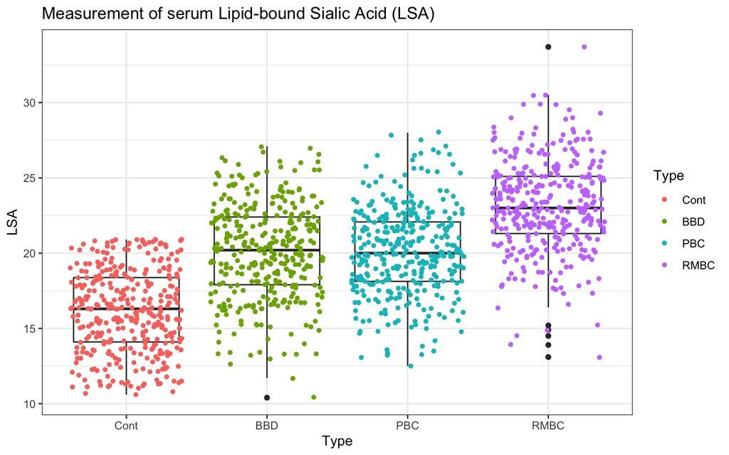

```r
# boxplot(LSA ~ Type, data = LSAdata_long)
# nicer
LSAdata_long %>% ggplot(aes(x = Type, y = LSA)) +
    geom_boxplot() +
#   geom_violin(draw_quantiles = c(0.25, 0.5, 0.75), scale = "area") +
    geom_jitter(aes(colour = Type), shape = 16, position = position_jitter(seed = 123)) +
    labs(title = "Measurement of serum Lipid-bound Sialic Acid (LSA)") +
    theme_bw()
```

# One-way ANOVA model estimation

## Simple model estimation

Now we estimate the model we know the data is in the right form (pivot_longer), and the categorical variable (factor) is ordered now. To estimate the ANOVA we can use the `aov` R function or the `lm` function at this point they are equivalent, and showing the results we use car function `Anova` or the R function `anova` can be used too.

```r
library(car)
# for the Anova function

# running a lm model for the ANOVA
LSAdata_lm <- lm(LSA ~ Type, data = LSAdata_long)
Anova(LSAdata_lm)
```

```
Anova Table (Type II tests)

Response: LSA
           Sum Sq   Df F value    Pr(>F)
Type       8683.9    3  330.33 < 2.2e-16 ***
Residuals 12232.9 1396
---
Signif. codes:  0 '***' 0.001 '**' 0.01 '*' 0.05 '.' 0.1 ' ' 1
```

```r
LSAdata_aov <- aov(LSA ~ Type, data = LSAdata_long)
Anova(LSAdata_aov)
```

```
Anova Table (Type II tests)

Response: LSA
           Sum Sq   Df F value    Pr(>F)
Type       8683.9    3  330.33 < 2.2e-16 ***
Residuals 12232.9 1396
---
Signif. codes:  0 '***' 0.001 '**' 0.01 '*' 0.05 '.' 0.1 ' ' 1
```

```r
summary(LSAdata_aov)
```

```
              Df Sum Sq Mean Sq F value Pr(>F)
Type           3   8684  2894.6   330.3 <2e-16 ***
Residuals   1396  12233     8.8
---
Signif. codes:  0 '***' 0.001 '**' 0.01 '*' 0.05 '.' 0.1 ' ' 1
```

# Post Hoc estimation

In the context of null hypothesis, the ANOVA model significance testing only indicates there is at least one factor (or more) average is different from the rest, we still need to do a *post hoc* multiple comparison test, like a Tukey Honesty Significant Difference HSD test (w-procedure). After running an ANOVA model estimation the next step is to determine which group means are significantly different from one another. There are different *post hoc* types of tests, the most common for parametric estimation of the model are Tukey HSD and Dunnett’s tests. It is well known that conducting several post hoc analyses carries the risk of dramatically inflate the probability of a type I error -concluding there is some sort of effect when in fact there is none.  
The library `emmeans` has a function to estimate the Tukey and 95% confidence intervals first the pairwise comparisons with the Control group and contrasts, and then we will compare each cancer condition to control to show if the averages are significant different. If the call to emmeans is with the factor `pairwise` emmeans function estimates a Tukey HSD pairwise for all the factor levels. If the call to emmeans is made with treatment vs. control the function estimates a Dunnett’s test comparing the control average (first factor) to the rest, to determine the significant difference.

```r
library(emmeans)

# Use emmeans to look for estimating the Tukey with 95% confidence intervals and Dunnett's test
emmeans(LSAdata_lm, pairwise ~ Type)
```

```
$emmeans
 Type emmean    SE   df lower.CL upper.CL
 Cont   16.1 0.158 1396     15.8     16.4
 BBD    20.1 0.158 1396     19.8     20.4
 PBC    20.1 0.158 1396     19.8     20.4
 RMBC   23.1 0.158 1396     22.8     23.5

Confidence level used: 0.95

$contrasts
 contrast    estimate    SE   df t.ratio p.value
 Cont - BBD   -3.9506 0.224 1396 -17.655  <.0001
 Cont - PBC   -3.9777 0.224 1396 -17.776  <.0001
 Cont - RMBC  -7.0146 0.224 1396 -31.347  <.0001
 BBD - PBC    -0.0271 0.224 1396  -0.121  0.9994
 BBD - RMBC   -3.0640 0.224 1396 -13.693  <.0001
 PBC - RMBC   -3.0369 0.224 1396 -13.571  <.0001

P value adjustment: tukey method for comparing a family of 4 estimates
```

```r
emmeans(LSAdata_lm, trt.vs.ctrl ~ Type)
```

```
$emmeans
 Type emmean    SE   df lower.CL upper.CL
 Cont   16.1 0.158 1396     15.8     16.4
 BBD    20.1 0.158 1396     19.8     20.4
 PBC    20.1 0.158 1396     19.8     20.4
 RMBC   23.1 0.158 1396     22.8     23.5

Confidence level used: 0.95

$contrasts
 contrast    estimate    SE   df t.ratio p.value
 BBD - Cont      3.95 0.224 1396  17.655  <.0001
 PBC - Cont      3.98 0.224 1396  17.776  <.0001
 RMBC - Cont     7.01 0.224 1396  31.347  <.0001

P value adjustment: dunnettx method for 3 tests
```

## Model estimation and post hoc estimate using rstatix library

Next following with the examples, using the tibble friendly `rstatix` library (wrappers for statistical tests in R), the ANOVA models are estimated with the `anova_test`

```r
library(rstatix)
LSAdata.aov_test <- LSAdata_long %>% anova_test(LSA ~ Type, effect.size = "ges", detailed = TRUE)
get_anova_table(LSAdata.aov_test)
```

```
ANOVA Table (type II tests)

  Effect      SSn      SSd DFn  DFd       F         p p<.05   ges
1   Type 8683.918 12232.88   3 1396 330.332 4.72e-162     * 0.415
```

```r
# with emmeans
LSAdata_long %>% emmeans_test(LSA ~ Type, p.adjust.method = "fdr", detailed = TRUE)
```

```
# A tibble: 6 × 14
  term  .y.   group1 group2 null.value estimate    se    df conf.low conf.high
* <chr> <chr> <chr>  <chr>       <dbl>    <dbl> <dbl> <dbl>    <dbl>     <dbl>
1 Type  LSA   Cont   BBD             0  -3.95   0.224  1396   -4.39     -3.51
2 Type  LSA   Cont   PBC             0  -3.98   0.224  1396   -4.42     -3.54
3 Type  LSA   Cont   RMBC            0  -7.01   0.224  1396   -7.45     -6.58
4 Type  LSA   BBD    PBC             0  -0.0271 0.224  1396   -0.466     0.412
5 Type  LSA   BBD    RMBC            0  -3.06   0.224  1396   -3.50     -2.63
6 Type  LSA   PBC    RMBC            0  -3.04   0.224  1396   -3.48     -2.60
# … with 4 more variables: statistic <dbl>, p <dbl>, p.adj <dbl>,
#   p.adj.signif <chr>
```

## Non parametric tests

Now we can analyze the same data using non-parametric tests. For substitute of a one-Way ANOVA we use Kruskal-Wallis to estimate the effects size and to estimate a post hoc pairwise multiple comparisons we execute a Dunn test, this test is based in a pairwise comparison of the ranked data, and te mean rank of the different group is compared all from the `rstatix` library. The Dunn test used to follow a Kruskal-Wallis test.

```r
# LSAdata_kruskal <- LSAdata_long %>% kruskal_test(LSA ~ Type)

# And estimate the Kruskal effect size
LSAdata_long %>% kruskal_effsize(LSA ~ Type)
```

```
# A tibble: 1 × 5
  .y.       n effsize method  magnitude
* <chr> <int>   <dbl> <chr>   <ord>
1 LSA    1400   0.416 eta2[H] large
```

```r
# To estimate the pairwise corrected by multiple comparisons the Dunn's Test
pc_LSAdata <- LSAdata_long %>% dunn_test(LSA ~ Type, p.adjust.method = "fdr")
pc_LSAdata
```

```
# A tibble: 6 × 9
  .y.   group1 group2    n1    n2 statistic         p     p.adj p.adj.signif
* <chr> <chr>  <chr>  <int> <int>     <dbl>     <dbl>     <dbl> <chr>
1 LSA   Cont   BBD      350   350   13.6    6.48e- 42 1.94e- 41 ****
2 LSA   Cont   PBC      350   350   13.5    1.35e- 41 2.69e- 41 ****
3 LSA   Cont   RMBC     350   350   24.1    7.24e-128 4.34e-127 ****
4 LSA   BBD    PBC      350   350   -0.0537 9.57e-  1 9.57e-  1 ns
5 LSA   BBD    RMBC     350   350   10.5    9.49e- 26 1.14e- 25 ****
6 LSA   PBC    RMBC     350   350   10.5    5.36e- 26 8.05e- 26 ****
```

# Permutation

Finally we do a different test, a permutation estimation for the effect size using a conditional inference procedure. For this example the test function the `coin` library for general model testing is `independence_test`, and the post hoc option is passed using the xtrafo with the mcp_trafo function. In this case the xvariable is `Type`.

```r
# load coin library for estimating permutations
library(coin)
# Permutations, using the coin package
set.seed(1234)
LSAdata_perm <- independence_test(LSA ~ Type, data=LSAdata_long,
                                  distribution = approximate(nresample = 10000),
                                  xtrafo = mcp_trafo(Type = "Tukey"))
# results
LSAdata_perm
```

```
    Approximative General Independence Test

data:  LSA by Type (Cont, BBD, PBC, RMBC)
maxT = 23.998, p-value < 1e-04
alternative hypothesis: two.sided
```

```r
# and the post hoc with subset pivotality condition violated
pvalue(LSAdata_perm, method="step-down")
```

```
BBD - Cont  <0.0001
PBC - Cont  <0.0001
RMBC - Cont <0.0001
PBC - BBD    0.9226
RMBC - BBD  <0.0001
RMBC - PBC  <0.0001
```

```r
LSAdata_aovp <- oneway_test(LSA ~ Type, data=LSAdata_long,
                  distribution=approximate(nresample=10000))
LSAdata_aovp
```

```
    Approximative K-Sample Fisher-Pitman Permutation Test

data:  LSA by Type (Cont, BBD, PBC, RMBC)
chi-squared = 580.82, p-value < 1e-04
```

```r
pvalue(LSAdata_aovp, method="step-down")
```

```
[1] <1e-04
99 percent confidence interval:
 0.0000000000 0.0005296914
```

## Really nice graphics

Now a really nice solution with nice well designed violin plots and corrected comparisons. Thanks to the really nice library `ggstatsplot`.

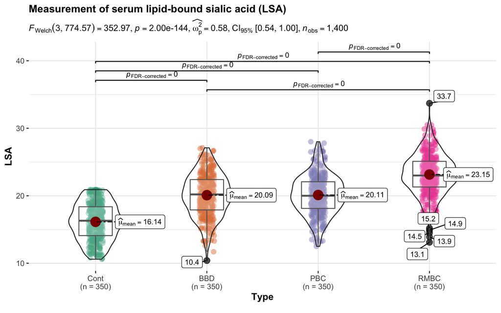

```r
library(ggstatsplot)

ggbetweenstats( data = LSAdata_long,
                x = Type,
                y = LSA,
                type = "p",
                pairwise.display = "s",
                p.adjust.method = "fdr",
                outlier.tagging = TRUE,
                title = "Measurement of serum lipid-bound sialic acid (LSA)" )
```